# Implementation of variants of the empirical Bayes Power Prior for normally distributed treatment effect summary measure

## Inference with the RMP

To perform inference, we would simply use:

```r
# Perform Bayesian inference based on observed target data.
model$inference(target_data = target_data)
```

This inference steps set the following attributes which, taken together, specify the posterior distribution.

```r
print(model$wpost) # Posterior weight
```

```
## [1] 0.8651748
```

```r
print(model$vague_posterior_mean)
```

```
## [1] 0.363183
```

```r
print(model$vague_posterior_variance)
```

```
## [1] 0.176125
```

```r
print(model$info_posterior_mean)
```

```
## [1] 0.47197
```

```r
print(model$info_posterior_variance)
```

```
## [1] 0.01348123
```

Now, let us see how this is implemented:

```r
inference <- function(target_data) {
  self$empirical_bayes_update(target_data)
  self$posterior_moments(target_data)
}
```

The first step in inference is to update the prior based on target_data if needed, in case where the method uses empirical Bayes. With empirical Bayes, some parameters of the prior are set based on observed target data. The second step is to compute the moments of the treatment effect posterior distribution. Note that we use the same inference function for all methods/scenarios combinations that do not require MCMC (in which case we need samples from the posterior and not only the parameters of the posterior).

In the study protocol, we specified that the variance of the vague component of the RMP should be such that this prior corresponds to the information provided by a single subject per arm in the target study. This is a form of empirical Bayes:

```r
empirical_bayes_update <- function(target_data) {
  if (self$empirical_bayes) {
    self$vague_prior_variance <- target_data$sample$treatment_effect_standard_error^2 * target_data$sample_size_per_arm # sample standard deviation in the target study
  } else {
    if (is.null(self$vague_prior_variance)) {
      stop("The vague prior variance must be defined if empirical_bayes is False")
    }
  }
}
```

The posterior is given by :

$$p(\theta_T | \boldsymbol{y}_S,
\boldsymbol{y}_T) = \widetilde{w}\mathcal{N}\left(\theta_T \bigg|
\frac{\mu_v}{N_T\frac{\sigma^2_v}{\sigma^2_T} + 1} +
\frac{\overline{y}_T}{\frac{\sigma^2_T}{N_T\sigma_v^2} + 1},
\left(\sigma_v^{-2} + \frac{N_T}{\sigma^2_T} \right)^{-1}\right) + (1-
\widetilde{w})\mathcal{N}\left(\theta_T \bigg|
\frac{\overline{y}_S}{N_T\frac{\nu^2_S}{\sigma^2_T} + 1} +
\frac{\overline{y}_T}{\frac{\sigma^2_T}{N_T\nu_S^2} + 1},
\left(\nu_S^{-2} + \frac{N_T}{\sigma^2_T} \right)^{-1}\right),$$

where $\mathcal{N}(\theta_T | \mu, \sigma^2)$ denotes the probability density function of a normal distribution with mean $\mu$ and variance $\sigma^2$, evaluated at $\theta_T$.

The code to compute the posterior moments is the following :

```r
posterior_moments <- function(target_data) {
  sample_mean <- target_data$sample$treatment_effect_estimate
  standard_error <- target_data$sample$treatment_effect_standard_error
  target_sample_size_per_arm <- target_data$sample_size_per_arm

  self$posterior_weight(target_data)


  vague_posterior_mean <- self$vague_prior_mean / (
    self$vague_prior_variance / standard_error^2 + 1
  ) + sample_mean / (
    1
    + standard_error^2
        / self$vague_prior_variance
  )
  vague_posterior_variance <- 1 / (
    1 / self$vague_prior_variance + 1 / standard_error^2
  )

  info_posterior_mean <- self$info_prior_mean / (
    self$info_prior_variance / standard_error^2 + 1
  ) + sample_mean / (
    1 + standard_error^2 / self$info_prior_variance
  )
  info_posterior_variance <- 1 / (
    1 / self$info_prior_variance + 1 / standard_error^2
  )

  self$vague_posterior_mean <- vague_posterior_mean
  self$vague_posterior_variance <- vague_posterior_variance
  self$info_posterior_mean <- info_posterior_mean
  self$info_posterior_variance <- info_posterior_variance

  self$post_mean <- self$posterior_mean()
  self$post_var <- self$posterior_variance()
}
```

With :

```r
posterior_mean <- function() {
  return((1 - self$wpost) * self$vague_posterior_mean + self$wpost * self$info_posterior_mean)
}
```

and :

```r
posterior_variance <- function() {
  post_var <- mixture_variance(
    self$wpost,
    self$info_posterior_variance,
    self$info_posterior_mean,
    self$vague_posterior_variance,
    self$vague_posterior_mean
  )
  return(post_var)
}
```

The variance of a mixture of two distributions is given by :

```r
mixture_variance <- function(w, sigma2A, muA, sigma2B, muB) {
  # Weighted sum of the variances
  weighted_var_sum <- w * sigma2A + (1 - w) * sigma2B

  # Weighted sum of the square of the means
  weighted_mean_sq_sum <- w * muA^2 + (1 - w) * muB^2

  # Square of the weighted sum of the means
  mean_weighted_sum_sq <- (w * muA + (1 - w) * muB)^2

  # Total variance of the mixture
  variance <- weighted_var_sum + weighted_mean_sq_sum - mean_weighted_sum_sq

  return(variance)
}
```

A crucial aspect of this inference step is the computation of the posterior mixture weights:

$$\tilde{w} = \frac{wC_v}{wC_v + (1-w)C_S}$$
Where $C_v$ and $C_S$ are proportional to the marginal likelihood (or prior predictive probability) of the aggregate data for each Gaussian component:
$$C_v
= \frac{1}{\sqrt{\sigma_v^2 +
\sigma^2_T/N_T}}\exp\left(-\frac{1}{2}\frac{(\overline{y}_T -
\mu_v)^2}{\sqrt{\sigma_v^2 + \sigma^2_T/N_T}}\right)$$
and :
$$C_S = \frac{1}{\sqrt{\nu_S^2 +
\sigma^2_T/N_T}}\exp\left(-\frac{1}{2}\frac{(\overline{y}_T -
\overline{y}_S)^2}{\sqrt{\nu_S^2 + \sigma^2_T/N_T}}\right)$$

```r
posterior_weight <- function(target_data) {
  sample_mean <- target_data$sample$treatment_effect_estimate
  sample_size_per_arm <- target_data$sample_size_per_arm
  standard_error <- target_data$sample$treatment_effect_standard_error

  if (is.null(sample_mean) || is.null(sample_size_per_arm)) {
    stop("One or more of the required variables (sample_mean, sample_size_per_arm) is NULL.")
  }

  likelihood_vague <- exp(
    -0.5
    * (sample_mean - self$vague_prior_mean)^2
      / (self$vague_prior_variance + standard_error^2)
  ) / sqrt(standard_error^2 + self$vague_prior_variance)
  likelihood_source <- exp(
    -0.5
    * (sample_mean - self$info_prior_mean)^2
      / (self$info_prior_variance + standard_error^2)
  ) / sqrt(target_data$sample$treatment_effect_standard_error^2 + self$info_prior_variance)
  wpost <- (
    self$w
      * likelihood_source
      / (self$w * likelihood_source + (1 - self$w) * likelihood_vague)
  )
  self$wpost <- wpost
  self$posterior_parameters$prior_weight <- self$wpost
  return(self$wpost)
}
```

This allows us to compute the posterior cdf and posterior pdf :

```r
posterior_pdf <- function(target_treatment_effect) {
  posterior_dist <- (1 - self$wpost) * dnorm(
    target_treatment_effect,
    mean = self$vague_posterior_mean,
    sd = sqrt(self$vague_posterior_variance)
  ) + self$wpost * dnorm(
    target_treatment_effect,
    mean = self$info_posterior_mean,
    sd = sqrt(self$info_posterior_variance)
  )
  return(posterior_dist)
}

posterior_cdf <- function(target_treatment_effect) {
  posterior_proba <- (1 - self$wpost) * pnorm(
    target_treatment_effect,
    mean = self$vague_posterior_mean,
    sd = sqrt(self$vague_posterior_variance)
  ) + self$wpost * pnorm(
    target_treatment_effect,
    mean = self$info_posterior_mean,
    sd = sqrt(self$info_posterior_variance)
  )
  return(posterior_proba)
}
```

Let us plot the posterior pdf :

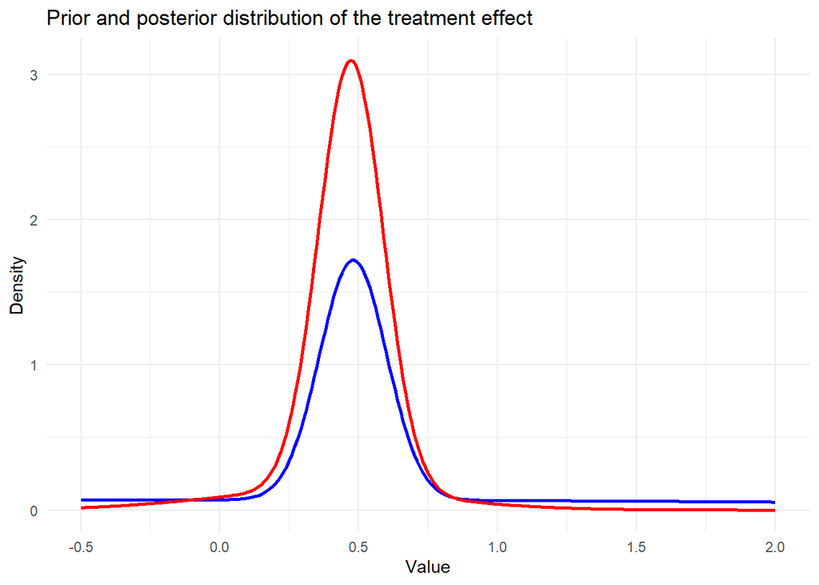

```r
library(ggplot2)
x_values <- seq(-0.5, 2, by = 0.01) # Range of values for x

prior_pdf <- model$prior_pdf(x_values)
posterior_pdf <- model$posterior_pdf(x_values)

df <- data.frame(x = x_values, prior_pdf = prior_pdf, posterior_pdf = posterior_pdf)

# Use ggplot2 to plot both PDFs on the same plot
ggplot2::ggplot(df, ggplot2::aes(x = x)) +
  geom_line(ggplot2::aes(y = prior_pdf), color = "blue", size = 1) +
  geom_line(ggplot2::aes(y = posterior_pdf), color = "red", size = 1) +
  ggplot2::labs(
    title = "Prior and posterior distribution of the treatment effect",
    x = "Value",
    y = "Density",
    labels = c("Prior pdf", "Posterior pdf")
  ) +
  theme_minimal() +
  scale_color_manual(values = c("blue", "red")) +
  guides(color = guide_legend(title = NULL)) +
  scale_fill_manual(
    name = "PDF of the robust mixture of Gaussians",
    labels = c("Prior pdf", "Posterior pdf"),
    values = c("blue", "red")
  )
```

Being able to sample from the posterior is crucial for estimating quantiles, we use the following:.

```r
sample_posterior <- function(n_samples) {
  component_choice <- sample(
    x = c(0, 1),
    size = n_samples,
    replace = TRUE,
    prob = c(1 - self$wpost, self$wpost)
  )


  samples <- rep(0, n_samples)

  samples[component_choice == 0] <- rnorm(
    n = sum(component_choice == 0),
    mean = self$vague_posterior_mean,
    sd = sqrt(self$vague_posterior_variance)
  )

  samples[component_choice == 1] <- rnorm(
    n = sum(component_choice == 1),
    mean = self$info_posterior_mean,
    sd = sqrt(self$info_posterior_variance)
  )

  return(samples)
}
```

Illustration of this sampling approach:

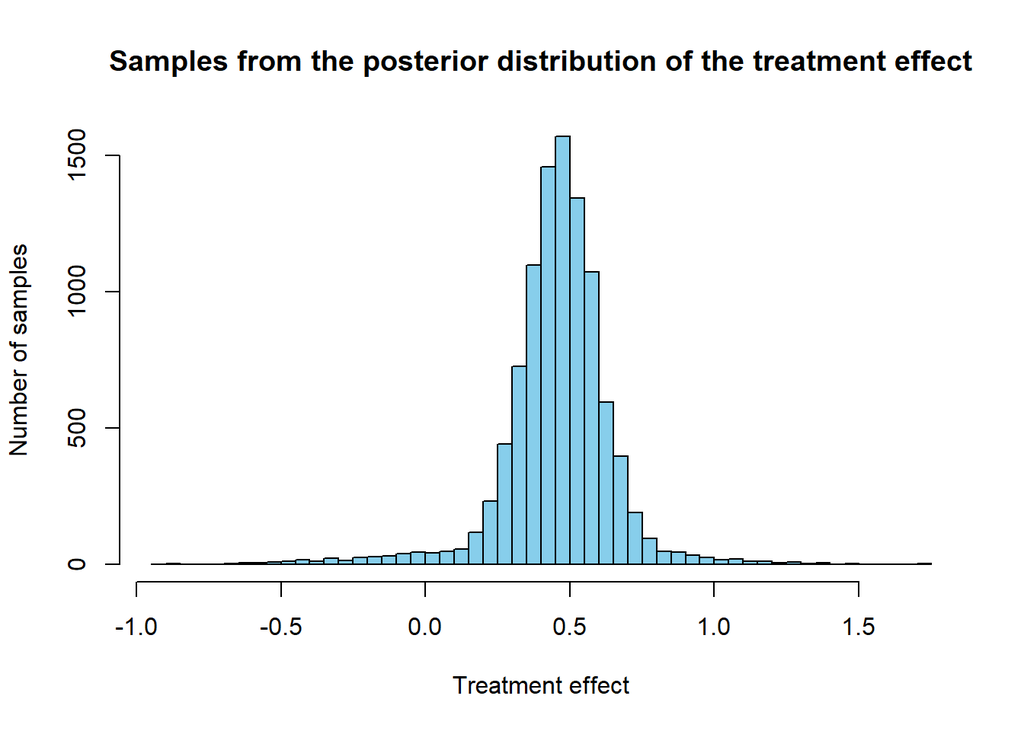

```r
samples <- model$sample_posterior(10000)
hist(samples, breaks = 60, col = "skyblue", main = "Samples from the posterior distribution of the treatment effect", xlab = "Treatment effect", ylab = "Number of samples")
```